# Dilettante reflections on cross polarization transfer in the solid state

Hampus Karlsson (hamka@chalmers.se/hkarlsson914@gmail.com) April 2022

## Introduction

This Jupyter notebook aim to investigate the topic of cross polarization (CP) transfers in solid state NMR experiments. This will be useful from several point of views, primarily to get a better understanding of how cross polarization work, but also to be able to quantitativly analyze certain NMR experiments and in the longer run, also analyze more complicated phenomena such as CP with off-resonant spin-locks (Lee Goldburg) and influence of relaxation etcetera. The starting point for doing this will be the following Hamiltonian:

\begin{align} \large{\bar{H} = \Omega_{I}\hat{I}_{Z}+\Omega_{S}\hat{S}_{Z}+\omega_{1,I}\hat{I}_{X}+\omega_{1,S}\hat{S}_{X}+2D(t)\hat{I}_{Z}\hat{S}_{Z}\tag{1} \\} \end{align}

Which is basically eq.83 from [1], it is the doubly rotating frame Hamiltonian with a time-dependent dipolar coupling introduced by magic angle spinning (MAS). The Hamiltonian in eq. 1 above is very similar to the highly useful, time-independent, doubly rotating frame Hamiltonian with a J-coupling term commonly encountered in solution state NMR (see for instance eq.14 in [2] or eq.5 in [3]). To my experience, working with the time-independent solution state counterpart (i.e. for instance eq.5 in [3]) is relativly straight forward and usually a very fruitful exercise when combined with the user friendly numpy/scipy python libraries and can lead to many powerful insights for most solution state NMR experiments. However, here I want to work with CP in the solid state and use the Hamiltonian in eq.1 above. The time- and crystalite orientation dependendency of dipolar coupling term makes this problem much more complicated. Both the time dependency and crystallite orientation depenedency needs to be adressed. I will attempt to do this by doing propagation of a density matrix in small, piecewise steps and by using powder averaging techniques.

## 1. Powder averaging

The following part will deal with the powder averaging question, yet another complicated topic in this context. So far I've found [4,5] to be very useful resources, especially [5] which provides C code for calculating diffent powder averages. The following section will thus straight away implement the calculation routines provided by [5].

```python
import numpy as np

# The following functions are my Python implementations of
# the C functions from (REF Eden_2003), Appendix A.

def get_num_zcw(M):

    '''Calculate the number of crystalites,
    see [5], Appendix A.'''

    k,l =3,5

    for i in range(M+1):
        sum = (l+k)
        k = l
        l = sum

    return sum


def create_zcw(m,sphere):

    '''Creates a set of ZCW crystal angles, based on
       [5], Appendix A. Returns a 2D matrix
       with crystalite angles the columns are:
       alpha, beta, gamma, weighting factor.'''

    if sphere == "full":
        c = [1.0,2.0,1.0]
    elif sphere == "hemi":
        c = [-1.0,1.0,1.0]
    elif sphere == "oct":
        c = [-1.0,1.0,4.0]

    N = get_num_zcw(m)
    g2 = get_num_zcw(m-2)
    angle_list = []

    for i in range(N-1):

        tmp_list = []
        tmp_list.append(2*np.pi*(np.fmod((i*g2/float(N)),1.0))/c[2])
        tmp_list.append(np.arccos(c[0]*(c[1]*np.fmod(i/float(N),1.0)-1.0)))
        tmp_list.append(0.0)
        tmp_list.append(1.0/float(N))
        angle_list.append(tmp_list)

    return np.asarray(angle_list)
```

## 2. Frame transformations, Hamiltonian and propagators

The following section will contain code for creation of hamiltonians, propagators, density matrices etcetera. Regarding the propagation the only strategy that is relevant for me is the one adopted by SIMPSON [6], to consider the Hamiltoninan piecewise time independent and calculate propagators for a small time step and then multiply them together in order to evolve the density operator over longer time intervals. Other approaches such as average hamiltonian theory [7] and Floquet theory [8] I will not conisder as they are at this point to challenging to me and I am already on thin ice doing what I am already doing.  
As aformentioned in section 1 the magnitude of the dipole coupling term will also be crystalite orientation dependent. So, in order to use eq. 1 dipolar interactions described in the "principal axis frame (PAS)" for each crystalite will need to be transformed from the crystalite PAS frame to the laboratory frame and from there, their magnitude will be handled by fourier series term included in D(t). The necessary evil way to do this is to work with "irreducible spherical tensors (IRT)" and "Wigner rotation matrices" [9] describes these concepts in great detail and provides instructions on how to create both the tensors and matrices. Ultimately a 2nd rank IRT is basically a row vector with five elements and a 2nd rand Wigner matrix a 5x5 matrix and a transformation of the interaction between two referecne frames becomes a vector matrix multiplicaiton (see for instance eq. 52 in [9]).

```python
from scipy.linalg import expm
from numpy import sin,cos,sqrt
import matplotlib.pyplot as plt


# Pauli spin matrices
u = 0.5 * np.array([[1., 0.],
                    [0., 1.]])

Ix = 0.5 * np.array([[0., 1.],
                     [1., 0.]])

Iy = 0.5j * np.array([[ 0., -1.],
                      [1.,  0.]])

Iz = 0.5 * np.array([[1., 0.],
                     [0.,-1.]])


# Create product operators, See [5,10,11]
puni = 2 * np.kron(u,u)
pIz = 2 * np.kron(Iz,u)
pSz = 2 * np.kron(u,Iz)
pIzSz = 2 * np.kron(Iz,Iz)

pIx = 2 * np.kron(Ix,u)
pIy = 2 * np.kron(Iy,u)
pIxSz = 2 * np.kron(Ix,Iz)
pIySz = 2 * np.kron(Iy,Iz)

pSx = 2 * np.kron(u,Ix)
pSy = 2 * np.kron(u,Iy)
pIzSx = 2 * np.kron(Iz,Ix)
pIzSy = 2 * np.kron(Iz,Iy)

pIxSx = 2 * np.kron(Ix,Ix)
pIySy = 2 * np.kron(Iy,Iy)
pIxSy = 2 * np.kron(Ix,Iy)
pIySx = 2 * np.kron(Iy,Ix)



def generate_wigner(omega):

    '''Builds a 5x5 Wigner rotation matrix from a set of euler angles,
       for the rotation of a 2nd rank IRT. See eq.49 and table 1 [9]'''

    a,b,g = omega

    # convert to radians
    a = np.deg2rad(a)
    b = np.deg2rad(b)
    g = np.deg2rad(g)

    # Empty array to be filled
    wig = np.zeros((5, 5),dtype=np.complex128)

    # The "Reduced Wigner Funcitons"
    d2mm = np.array([[   0.25*(1+cos(b))**2,     -0.5*sin(b)*(1+cos(b)), sqrt(3/8)*sin(b)**2,     -0.5*sin(b)*(1-cos(b)),     0.25*(1-cos(b))**2],

                     [0.5*sin(b)*(1+cos(b)), 0.5*(2*cos(b)**2+cos(b)-1), -sqrt(3/8)*sin(2*b), 0.5*(2*cos(b)**2-cos(b)-1), -0.5*sin(b)*(1-cos(b))],

                     [  sqrt(3/8)*sin(b)**2,         sqrt(3/8)*sin(2*b), 0.5*(3*cos(b)**2-1),        -sqrt(3/8)*sin(2*b),    sqrt(3/8)*sin(b)**2],

                     [0.5*sin(b)*(1-cos(b)), -0.5*(2*cos(b)**2-cos(b)-1), sqrt(3/8)*sin(2*b), 0.5*(2*cos(b)**2+cos(b)-1), -0.5*sin(b)*(1+cos(b))],

                     [   0.25*(1-cos(b))**2,       0.5*sin(b)*(1-cos(b)), sqrt(3/8)*sin(b)**2,     0.5*sin(b)*(1+cos(b)),     0.25*(1+cos(b))**2]])

    mp = [2, 1, 0, -1, -2]
    m = [2, 1, 0, -1, -2]

    for row in range(5):

        for col in range(5):
            # build final matrix using eq.49 [9]
            wig[row, col] = np.exp(-1j*mp[row]*a)*d2mm[row,col]*np.exp(-1j*m[col]*g)

    return wig




def generate_D_of_t(IRT_lab, MAS, beta, t):

    '''Calculates dipolar coupling for a time t for a
       particlar lab fram tensor. See eq.89 [1]'''

    beta = np.deg2rad(beta)

    d2m0 = np.array([sqrt(3/8)*sin(beta)**2, -sqrt(3/8)*sin(2*beta), 0.5*(3*cos(beta)**2-1),
                     sqrt(3/8)*sin(2*beta), sqrt(3/8)*sin(beta)**2])

    D = 0
    n = [-2,-1,0,1,2]

    for i in range(5):
        # Fourier series in eq. 89 in [1].
        D+= IRT_lab[i]*d2m0[i]*np.exp(-1j*n[i]*MAS*2*np.pi*t)

    return D




def generate_hamiltonian(omega_I, omega_S, w1Ix, w1Sx, IRT_lab, theta_magic, MAS,t):

    '''Calculates the time-dependent Hamiltonian based on eq.1,
       takes offsets and RF strengths and a lab frame IRT as arguments.'''

    # Convert to rad/s
    omega_I = 2*np.pi*omega_I
    omega_S = 2*np.pi*omega_S

    w1Ix = 2*np.pi*w1Ix
    w1Sx = 2*np.pi*w1Sx

    IRT_lab = 2*np.pi*IRT_lab

    Dt = generate_D_of_t(IRT_lab, MAS, theta_magic, t)

    # Final hamiltonian for particular time point
    H = omega_I*pIz + omega_S*pSz + w1Ix*pIx + w1Sx*pSx + Dt*pIzSz

    return H




def generate_propagator(hams,dt):

    '''Creates a propagator over a certain time interval.
       Takes a time ordered list of Hamiltonians and the short time over which
       the Hamiltonians are considered time indepeendent. See eq.4 in [6]'''

    # exponentiate all hamiltonians
    hams = [expm(-1j*h*dt) for h in hams]

    U = np.copy(hams[0])

    # multiply them together
    for i in range(1,len(hams),1):
        U = np.dot(hams[i],U)

    return U



def generate_propagators(hams,inds,dt):

    '''Creates a list of propagators to time points specified
       by indices in  the list "inds"'''

    # exponentiate all hamiltonians
    hams = [expm(-1j*h*dt) for h in hams]

    U = np.copy(hams[0])

    props = []

    # multiply them together
    for i in range(1,len(hams),1):

        U = np.dot(hams[i],U)

        if i in inds:
            props.append(np.copy(U))

    return props



def check_content(p):

    '''Prints out content of density matrix in more readable manner.'''

    poperators = [puni,pIz,pSz,pIzSz,pIx,pIy,
                  pIxSz,pIySz,pSx,pSy,pIzSx,pIzSy,
                  pIxSx,pIySy,pIxSy,pIySx]

    mag_poperator_real = []
    mag_poperator_imag = []

    for pop in poperators:
        mag_poperator_real.append(round(np.trace(np.dot(pop, p)).real,3))
        mag_poperator_imag.append(round(np.trace(np.dot(pop, p)).imag, 3))


    print("puni,pIz,pSz,pIzSz,pIx,pIy,pIxSz,pIySz,pSx,pSy,pIzSx,pIzSy,pIxSx,pIySy,pIxSy,pIySx")
    print(mag_poperator_real)
    print(mag_poperator_imag)



def calc_index(wnt_tpnt_ind,tpnts):

    '''Takes a list of time points, returns a list with
       indices corresponding to time points specifed in wnt_tpnt_ind'''

    inds = []

    for i in range(len(tpnts)):

        tp = tpnts[i]
        if np.around(tp,decimals=4) in wnt_tpnt_ind:
            inds.append(i)

    return inds
```

## 3a. Experimental paramters

The following section will specify some experimental parameters.

```python
import matplotlib.pyplot as plt

# Specify some experimental parameters for simulation
#-----------------------------------------------------

dt = 1E-6                                                                     # time-step (sec)
sim_duration = 800.0E-6                                                       # (sec)
time_points = np.arange(0.0, sim_duration, dt)
obs_time_points = [0.0, 25E-6, 50E-6, 100E-6, 200E-6, 300E-6, 400E-6, 550E-6]
obs_time_inds = [0, 25, 50, 100, 200, 300, 400, 500, 600, 700, 750]


SL_1H = 50000.0                                                                # Hz
SL_13C = 70000.0                                                               # Hz

offset_1H = 0.0                                                                # Hz
offset_13C = 0.0                                                               # Hz

MAS = 10000.0                                                                  # Hz
magic_angle = 54.74                                                            # degrees


# Calculate the H-C dipolar coupling see [12]
#-----------------------------------------------------

gamma_1H = 42.577478518E6                                                      # Hz/T
gamma_13C = 10.7084E6                                                          # Hz/T
r = 1.1E-10                                                                    # H-C bond length (meter)
h_bar = 1.054571817E-34                                                        # Reduced plancks constant (J*s/rad)
u0 =  4*np.pi*1E-7                                                             # vacuum permeability  (T*m/A)
bjk = -(u0*h_bar*gamma_1H*gamma_13C)/(4*np.pi*r**3)                            # in Hz for the moment


# Create the PAS frame IRT for the dipole coupling
dip_PAS_IRT = np.array([0.0, 0.0, np.sqrt(3/2)*bjk, 0.0, 0.0])

# Create powder
crystalites = create_zcw(4,"full")
```

## 3b. Dipole coupling under MAS

The following cell inspects the magnitude and behaviour of the dipole coupling over a couple of rotor periods.

```
Number of crystalites are = 54
Magic angle is = 54.74 degrees, average D(t) = -5.426337463003028 Hz
```

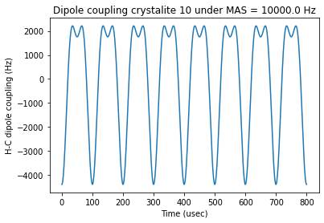

```python
# Check D(t) for some random crystal
rand_cryst = 10
cryst_angles = np.rad2deg(crystalites[rand_cryst,:-1])
eul_ang_trip = (cryst_angles[0], cryst_angles[1], cryst_angles[2])
D_PAS2LAB = generate_wigner(eul_ang_trip)
dip_LAB_IRT = np.dot(dip_PAS_IRT,D_PAS2LAB)
dipol = generate_D_of_t(dip_LAB_IRT,MAS,magic_angle,time_points).real

print("Number of crystalites are = "+str(crystalites.shape[0]))
print("Magic angle is = "+str(magic_angle)+" degrees, average D(t) = "+str(np.average(dipol))+" Hz")

plt.plot(time_points/1E-6,dipol)
plt.title("Dipole coupling crystalite "+str(rand_cryst)+" under MAS = "+str(MAS)+" Hz")
plt.ylabel("H-C dipole coupling (Hz)")
plt.xlabel("Time (usec)")
plt.show()
```

## 3c. Simulation of actual CP transfer under MAS

The following cell simulates an actual CP transfer and calculates the average Sx magnetization over all crystalites for a couple of time points.

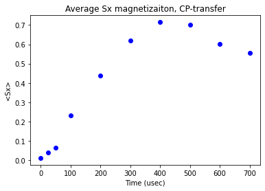

```python
# Simulate <Sx> as function of time:
#-----------------------------------------------------

# starting density matrix
p0 = np.copy(pIx)


# Empty matrix to hold Sx magnetization for each crystalite at observation time points
obs_mag = np.zeros((crystalites.shape[0],len(obs_time_inds)),dtype=np.complex128)


# Loop through the crystalites and do calculation for each one:
for i in range(crystalites.shape[0]):

    #if i % 10 == 0:
     #   print(i)

    # Grab one crystal
    cryst_angles = np.rad2deg(crystalites[i,:-1])
    eul_ang_trip = (cryst_angles[0], cryst_angles[1], cryst_angles[2])
    D_PAS2LAB = generate_wigner(eul_ang_trip)

    # rotate dipole tensor for crystalite from PAS frame to Lab frame
    dip_LAB_IRT = np.dot(dip_PAS_IRT,D_PAS2LAB)

    # Hamiltonians
    saved_hamiltonians = []

    for time in time_points:

        H_t = generate_hamiltonian(offset_1H, offset_13C, SL_1H, SL_13C,
                                   dip_LAB_IRT, magic_angle, MAS, time)

        saved_hamiltonians.append(H_t)

    # Create propagators for time points specified earlier
    Us = generate_propagators(saved_hamiltonians,obs_time_inds,dt)

    for k in range(len(Us)):
        # Calculate Sx for each time point/propator
        U = Us[k]
        U_dagger = np.transpose(np.conjugate(U))
        p1 = np.dot(U,np.dot(p0,U_dagger)) # eq.2 Bak2000
        Sx = np.trace(np.dot(pSx,p1))
        obs_mag[i,k] = Sx


# Calculate average Sx magnetization for all crystals
mSx_avg = np.average(obs_mag, axis=0)
plt.plot(np.asarray(obs_time_inds)[:-1],mSx_avg.real[:-1],"bo")
plt.title("Average Sx magnetizaiton, CP-transfer")
plt.ylabel("<Sx>")
plt.xlabel("Time (usec)")
plt.show()
```

## 3d. Simulate Hartmann Hahn matching profile for CP transfer under MAS

The following cell simulates the matching conditons, by looping through 1H filed strengths from 40-100 kHz while the filed stregnth for 13C is still 70 kHz.

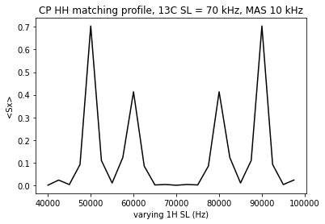

```python
# Simulate Sx as function of SL HH match:
# -----------------------------------------------------

many_sl_1H = np.arange(40000.0,100000.0,2500.0)
new_avg_Sx = np.zeros((many_sl_1H.shape[0]))

for h in range(many_sl_1H.shape[0]):

    proton_sl = many_sl_1H[h]
    Sx = 0.0

    for i in range(crystalites.shape[0]):

        #if i % 10 == 0:
        #    print(i)

        # Grab one crystal
        cryst_angles = np.rad2deg(crystalites[i,:-1])
        eul_ang_trip = (cryst_angles[0], cryst_angles[1], cryst_angles[2])
        D_PAS2LAB = generate_wigner(eul_ang_trip)

        # rotate dipole tensor for crystalite from PAS frame to Lab frame
        dip_LAB_IRT = np.dot(dip_PAS_IRT,D_PAS2LAB)

        # Hamiltonians
        saved_hamiltonians = []

        for time in time_points[0:600]:

            H_t = generate_hamiltonian(offset_1H, offset_13C, proton_sl, SL_13C,
                                       dip_LAB_IRT, magic_angle, MAS, time)

            saved_hamiltonians.append(H_t)

        # Create propagators for time points specified earlier
        U = generate_propagator(saved_hamiltonians,dt)
        U_dagger = np.transpose(np.conjugate(U))
        p1 = np.dot(U,np.dot(p0,U_dagger)) # eq.2 Bak2000
        crystalite_Sx = np.trace(np.dot(pSx,p1))
        Sx += crystalite_Sx

    new_avg_Sx[h] = Sx.real/crystalites.shape[0]

plt.plot(many_sl_1H,new_avg_Sx,"k-")
plt.title("CP HH matching profile, 13C SL = 70 kHz, MAS 10 kHz")
plt.ylabel("<Sx>")
plt.xlabel("varying 1H SL (Hz)")
plt.show()
```

## References

1. Rovnyak, D. (2008). Tutorial on analytic theory for cross‐polarization in solid state NMR. Concepts in Magnetic Resonance Part A: An Educational Journal, 32(4), 254-276.
2. Allard, P., Helgstrand, M., & Härd, T. (1997). A method for simulation of NOESY, ROESY, and off-resonance ROESY spectra. Journal of Magnetic Resonance, 129(1), 19-29.
3. Allard, P., Helgstrand, M., & Härd, T. (1998). The complete homogeneous master equation for a heteronuclear two-spin system in the basis of cartesian product operators. Journal of Magnetic Resonance, 134(1), 7-16.
4. Bak, M., & Nielsen, N. C. (1997). REPULSION, a novel approach to efficient powder averaging in solid-state NMR. Journal of Magnetic Resonance, 125(1), 132-139.
5. Edén, M. (2003). Computer simulations in solid‐state NMR. III. Powder averaging. Concepts in Magnetic Resonance Part A: An Educational Journal, 18(1), 24-55.
6. Bak, M., Rasmussen, J. T., & Nielsen, N. C. (2011). SIMPSON: a general simulation program for solid-state NMR spectroscopy. Journal of magnetic resonance, 213(2), 366-400.
7. Brinkmann, A. (2016). Introduction to average Hamiltonian theory. I. Basics. Concepts in Magnetic Resonance Part A, 45(6), e21414.
8. https://github.com/tesch1/GAMMA/tree/master/doc/pdf/modules/floquet (accessed 2022-04-26, 17:02)
9. Edén, M. (2003). Computer simulations in solid‐state NMR. I. Spin dynamics theory. Concepts in Magnetic Resonance Part A: An Educational Journal, 17(1), 117-154.
10. Levitt, M.H. Spin Dynamics, Basics of Nucelar Magnetic Resonance (2001) John Wiley & Sons, pp.356
11. Cavanagh, J. et al. Protein NMR Spectroscopy: Principles and Practice 2nd ed. (2007) Elsevier, section 2.2.5
12. https://www.lorieau.com/nmr/2016/03/06/dipolar-couplings.html (accessed 2022-04-27 12:22)